# Wind Turbines Data Analysis

L. N.

2022-09-24

## Introduction

The influence of wind energy as a renewable source of energy has been advocated considerably for the past decades. The method of harvesting energy from the wind is through what are known as wind turbines. Wind turbines are self explanatory, they’re turbines that have large vaned wheels rotated by the wind to generate electricity. Wind turbines also have a certain capacity that they’re able to generate, but what components of turbines, if any, are directly correlated to the turbine capacity?

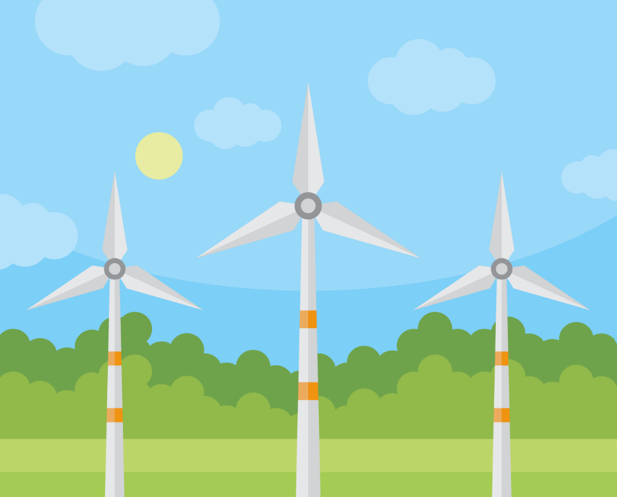

We will be exploring that question by analyzing turbine data that was gathered from the Federal Aviation Administration’s (FAA) Digital Obstacle File (DOF) and Obstruction Evaluation Airport Airspace Analysis (OE-AAA), the American Clean Power Association (ACP), Lawrence Berkeley National Laboratory (LBNL), and the United States Geological Survey (USGS). According to the United States Wind Turbine Database (USWTDB), the data for technical specifications for turbines were assigned based on the wind turbine make and models as provided by manufacturers and project developers directly, and via FAA datasets, information on the wind project developer or turbine manufacturer websites, or other online sources. What we’re interested in from this data is the quantitative variable called “Turbine.Capacity”, which tells us the electrical generation capacity of the turbine measured in KW (kilo-watts), and we’ll call that our outcome variable. We’ll be comparing our outcome variable to three other quantitative variables, namely “Turbine.Hub_Height”, “Turbine.Rotor_Diameter”, and “Turbine.Swept_Area”, and we’ll call those our predictor variables. “Turbine.Hub_Height” tells us the height in meters of the turbine’s hub, “Turbine.Rotor_Diameter” tells us the diameter in meters of the turbine’s rotor, and “Turbine.Swept_Area” tells us the area swept in each rotation of the turbine’s rotor. We’ll begin by analyzing the univariate distributions of our outcome variable and predictor variables. Then, we’ll analyze the bivariate distributions of our outcome variable to each of the predictor variables. Finally, we’ll conclude our findings by comparing the relationships between the outcome variable and the predictor variables.

## Univariate Distributions

### Outcome Variable

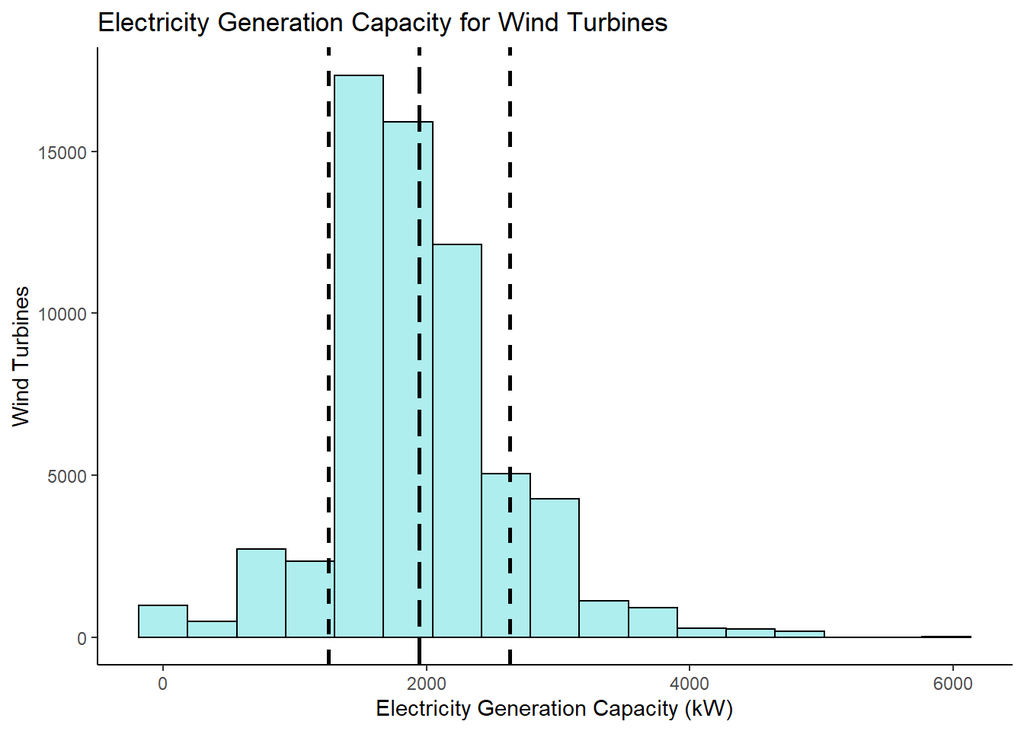

Figure 1: Histogram distribution of electricity generation capacity (in kilowatts) for wind turbines. The capacity ranges from 50 to 6000 kW. The long dashes represent the mean, while the short dashes represent +1 and -1 standard deviation of the mean.

There are 63961 wind turbines. The distribution of turbine capacity is unimodal and approximately symmetric, with a mean of 1945.3 and a standard deviation of 689.73. There is also a potential outlier at 6000 kW turbine capacity.

### Predictor Variables

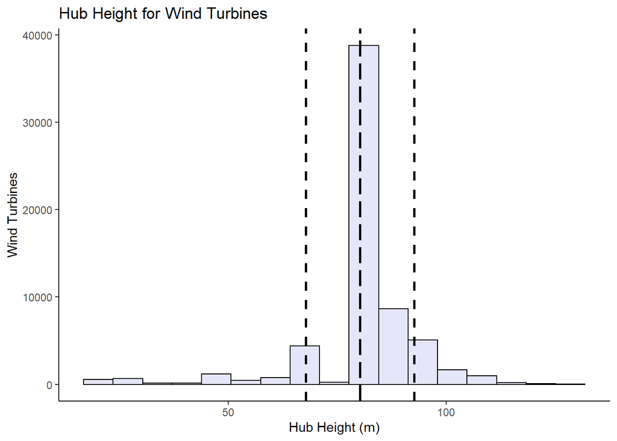

Figure 2: Histogram distribution of hub height (in meters) for wind turbines. The hub height ranges from 22.8 to 131 m. The long dashes represent the mean, while the short dashes represent +1 and -1 standard deviation of the mean.

The distribution of turbine hub height is unimodal and approximately symmetric, with a mean of 80.27 and a standard deviation of 12.47.

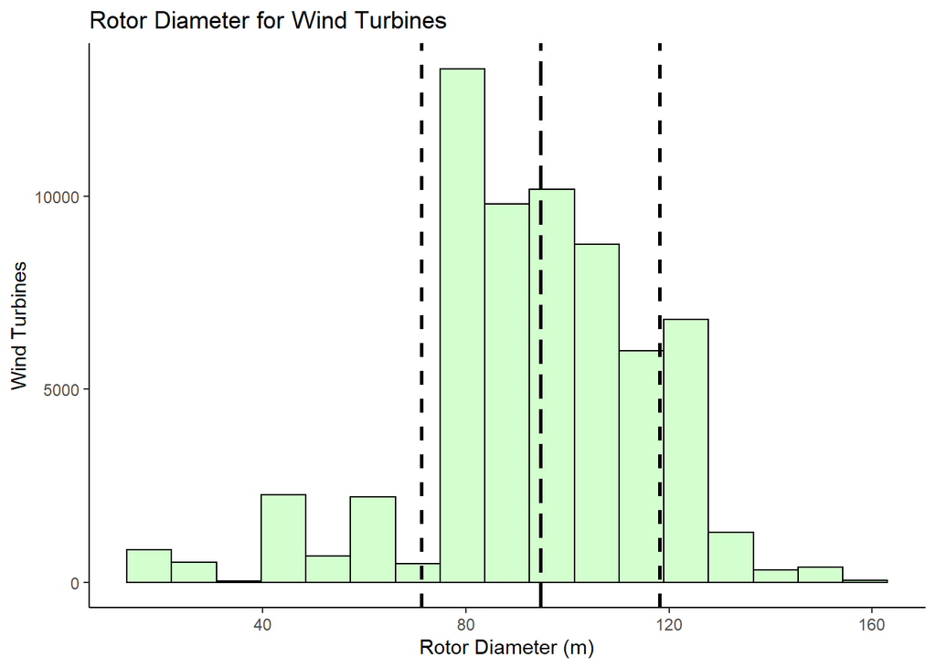

Figure 3: Histogram distribution of rotor diameter (in meters) for wind turbines. The rotor diameter ranges from 14 to 155 m. The long dashes represent the mean, while the short dashes represent +1 and -1 standard deviation of the mean.

The distribution of turbine rotor diameter is unimodal and approximately symmetric, with a mean of 94.68 and a standard deviation of 23.45.

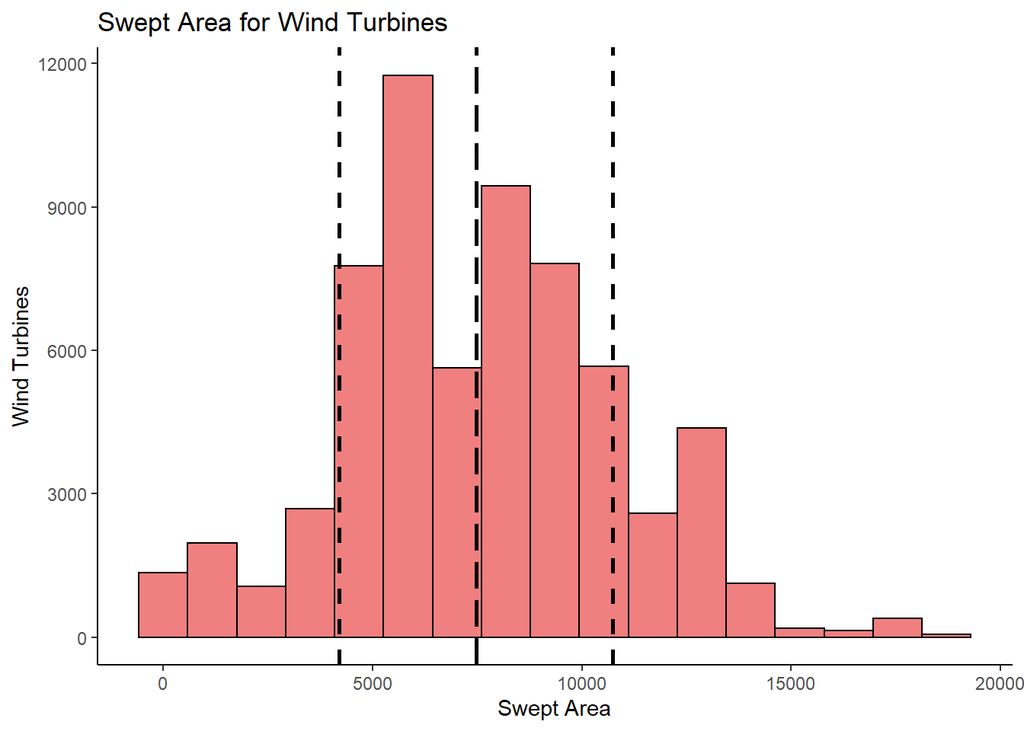

Figure 4: Histogram distribution of swept area for wind turbines. The swept area ranges from 153.94 (min) to 18869.19 (max). The long dashes represent the mean, while the short dashes represent +1 and -1 standard deviation of the mean.

The distribution of turbine swept area is bimodal and approximately symmetric, with a mean of 7472.67 and a standard deviation of 3267.17.

## Bivariate Relationships

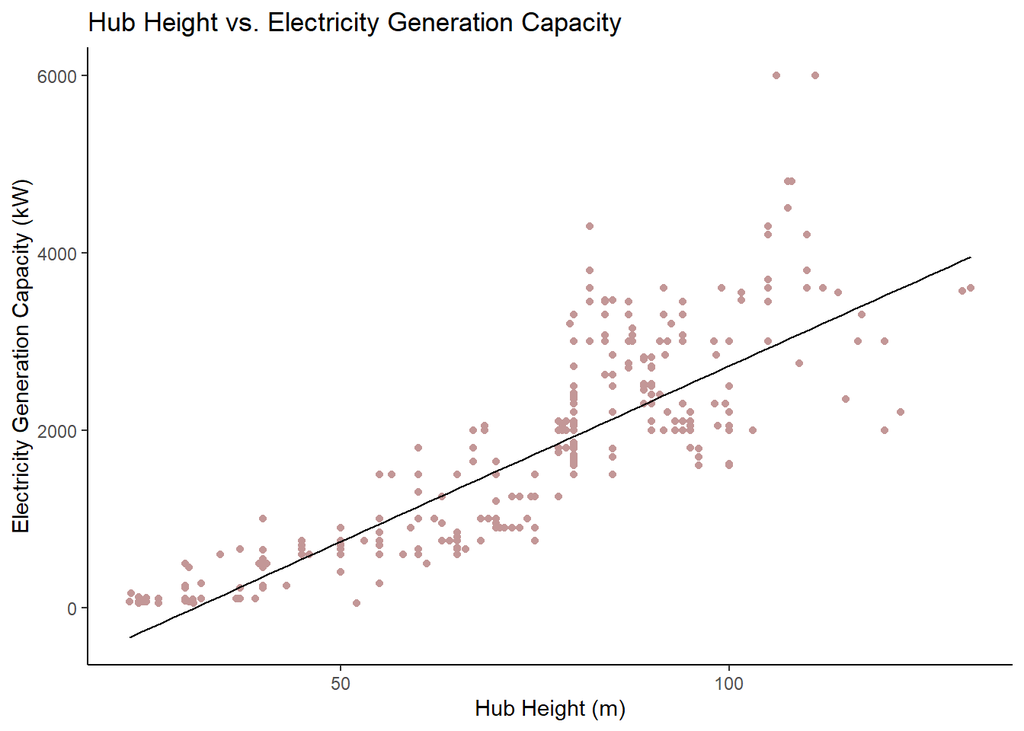

Figure 5: Scatterplot distribution between hub height (in meters) and electricity generation capacity (in kilowatts) for wind turbines. The line of best fit has been included.

There is a positive, strong, and linear relationship between turbine hub height and turbine capacity, with a correlation coefficient of 0.72.

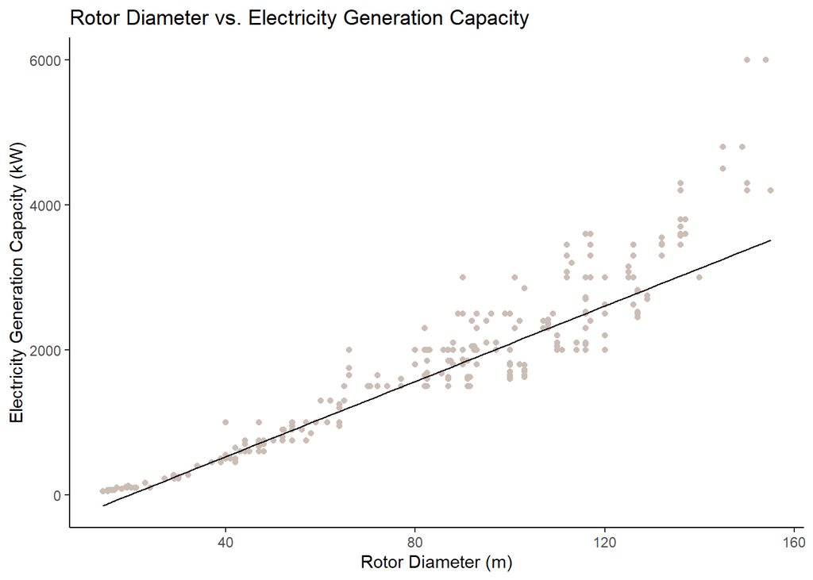

Figure 6: Scatterplot distribution between rotor diameter (in meters) and electricity generation capacity (in kilowatts) for wind turbines. The line of best fit has been included.

There is a positive, very strong, and linear relationship between turbine rotor diameter and turbine capacity, with a correlation coefficient of 0.88

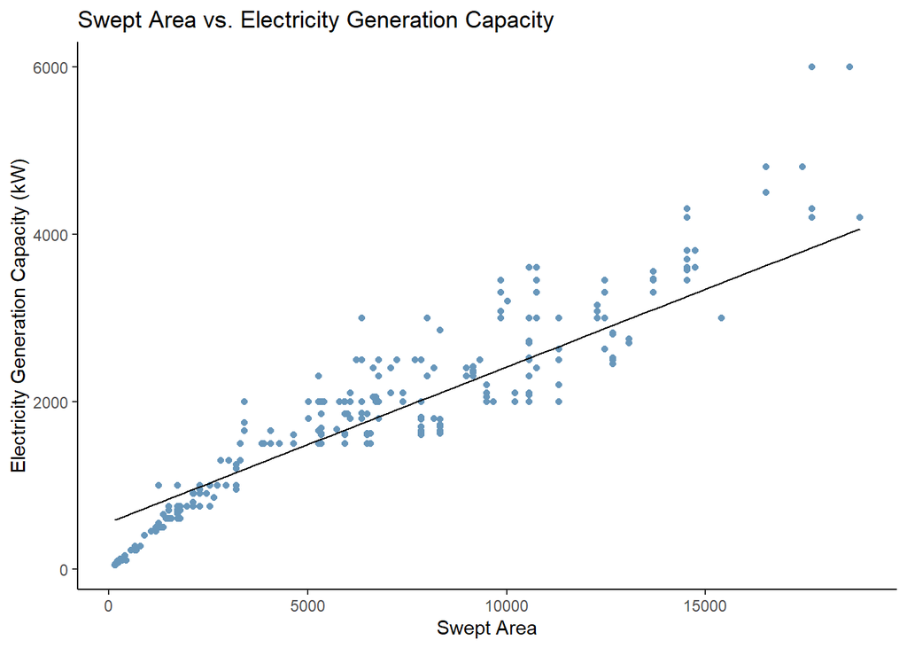

Figure 7: Scatterplot distribution between swept area and electricity generation capacity (in kilowatts) for wind turbines. The line of best fit has been included.

There is a positive, very strong, and linear relationship between turbine swept area and turbine capacity, with a correlation coefficient of 0.88

## Conclusion

### Findings

The relationships between our outcome variable (electricity generation capacity) and our predictor variables (hub height, rotor diameter, and area swept) are all strong, positive, and linear. Moreover, rotor diameter and swept area both shared a very strong correlation coefficient of 0.88, while hub height had a strong correlation coefficient of 0.72. This suggests that hub height, rotor diameter, and swept area were all correlated to electricity generation capacity. This can also be viewed as when hub height, rotor diameter, and swept area of turbines increase, electrical generation capacity of turbines also increase. Future research in areas related to wind turbines could be in mechanical and electrical engineering. Mechanical engineers design and construct the turbine components, like the hub and the rotors, while electrical engineers design the electrical generation capacity units for the turbines.

### References

Hoen, B.D., Diffendorfer, J.E., Rand, J.T., Kramer, L.A., Garrity, C.P., and Hunt, H.E., 2018, United States Wind Turbine Database (ver. 5.1, August 2022): U.S. Geological Survey, American Clean Power (ACP) Association, and Lawrence Berkeley National Laboratory data release  
2022 CORGIS Datasets Project. Project by Austin Cory Bart, Dennis Kafura, Clifford A. Shaffer, Javier Tibau, Luke Gusukuma, Eli Tilevich.  
More information of the turbine data used can be found at https://www.sciencebase.gov/catalog/item/57bdfd8fe4b03fd6b7df5ff9  
The image used can be found at https://static.vecteezy.com/system/resources/previews/000/173/679/original/wind-turbine-vector.png